# Homework #4

Guang Yi Lim

3/5/2018

## Chick weights

The `ChickWeight` data set is part of the base package `datasets`. See `?ChickWeight` for details on the data. For all of the questions use `dplyr` functions with the pipe `%>%` whenever possible.

**Submission instructions**: Create a folder named `ds202_hw4`, and name the RMarkDown file including your solutions `hw4.Rmd` under this folder. For the submission, create a GitHub repository named `ds202_hw4` under your GitHub account, and push both `hw4.Rmd` and the knitted `hw4.html` before the deadline. I will assume you use the same GitHub username as for your HW3 submission. The latest version of your homework appearing on GitHub before the deadline is graded. *It is crucial to follow the exact folder structure and file names*, so that your homework can be reproduced and graded by an automated script. This homework is **due on March 7** before class.

1. Get a frequency breakdown of the number of chicks, their average weight and the standard deviation of the weights in each of the diets at the start of the study. Store the resulting data frame in a variable named `weight0` and print.

```r
weight0 <- data %>%
  group_by(Diet) %>%
  summarise(NumChicks = n()%/%12 ,average_weight = mean(weight),sd_weight = sd(weight))
weight0
```

```
## # A tibble: 4 x 4
##   Diet  NumChicks average_weight sd_weight
##   <fct>     <dbl>          <dbl>     <dbl>
## 1 1            18           103.      56.7
## 2 2            10           123.      71.6
## 3 3            10           143.      86.5
## 4 4             9           135.      68.8
```

2. Each chick should have twelve weight measurements. Use the dplyr package to identify how many measurements are there for each chick. Extract a subset of the data for all chicks with complete information, name the data set `complete`, and print the first 3 rows. (Hint: you might want to use mutate to introduce a helper variable consisting of the number of observations)

```r
complete <- data %>% group_by(Chick) %>% mutate(Num = n()) %>% filter(Num ==12)
head(complete, n=3)
```

```
## # A tibble: 3 x 5
## # Groups:   Chick [1]
##   weight  Time Chick Diet    Num
##    <dbl> <dbl> <ord> <fct> <int>
## 1     42     0 1     1        12
## 2     51     2 1     1        12
## 3     59     4 1     1        12
```

3. In the complete data set introduce a new variable that measures the current weight difference compared to day 0. Name this variable weightgain and print the first 3 rows of the new data frame.

```r
complete <- complete %>%
  group_by(Chick) %>%
  mutate (weightGain = (weight - weight[Time ==0]))
head(complete, n=3)
```

```
## # A tibble: 3 x 6
## # Groups:   Chick [1]
##   weight  Time Chick Diet    Num weightGain
##    <dbl> <dbl> <ord> <fct> <int>      <dbl>
## 1     42     0 1     1        12          0
## 2     51     2 1     1        12          9
## 3     59     4 1     1        12         17
```

4. Use `{ggplot2}` to create side-by-side boxplots of `weightgain` by `Diet` for day 21. Describe the relationship in 2-3 sentences. Change the order of the categories in the Diet variable such that the boxplots are ordered by median `weightgain`, and the lower limit of the y axis should be 0.

```r
day21 <- filter(complete, Time ==21)
p1 <- temp <- ggplot(day21,aes(x = reorder(Diet,weightGain,FUN = median),y =weightGain))+geom_boxplot() + expand_limits(y=0) +  xlab("Diet") +ylab("Weight Gain")+ ggtitle("Weight Gain by day 21 ")
p1 <- p1 + theme(plot.title = element_text(hjust=0.5))
```

[output not shown]

5. Answer the following question using numerical and graphical summary: Which chick gained the most weight and which gained the least weight? What diets were they on?

```r
most <- day21 %>% arrange(desc(weightGain))
head(most,n=1)
```

```
## # A tibble: 1 x 6
## # Groups:   Chick [1]
##   weight  Time Chick Diet    Num weightGain
##    <dbl> <dbl> <ord> <fct> <int>      <dbl>
## 1    373    21 35    3        12        332
```

```r
tail(most,n=1)
```

```
## # A tibble: 1 x 6
## # Groups:   Chick [1]
##   weight  Time Chick Diet    Num weightGain
##    <dbl> <dbl> <ord> <fct> <int>      <dbl>
## 1     74    21 24    2        12         32
```

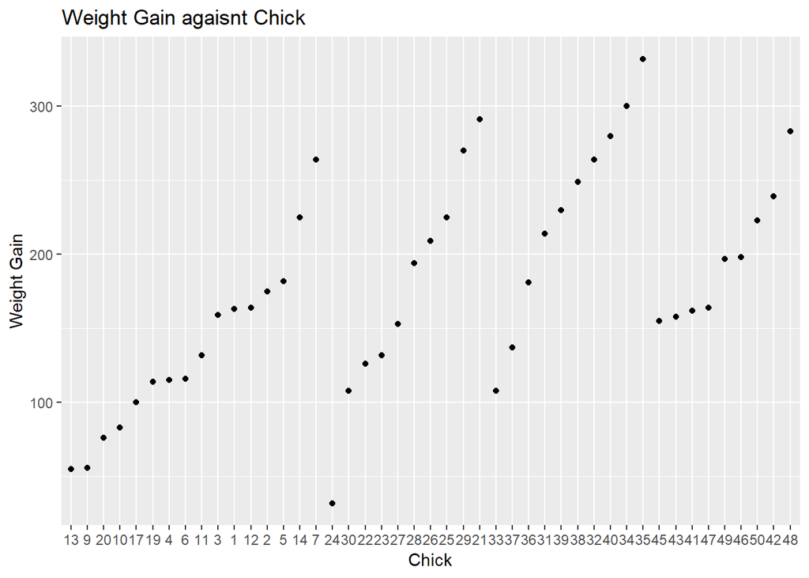

```r
ggplot(most,aes(x = Chick,y =weightGain)) +geom_point()+xlab("Chick")+ylab("Weight Gain")+ggtitle("Weight Gain agaisnt Chick")
```

Chick35 gained the most weight. It was on diet 3.Chick24 gained the least weight, it was on diet 2.

6. For the chicks with the least and the most weight at time 0, plot their growth trajectories over time.  
5 pts of extra credit: Add to the plot the average growth trajectory for all chicks (calculated as the mean weight for each chick at each time). How do the trajectories compare?

```r
day0 <- complete %>% filter(Time ==0)%>% arrange(desc(weight))
head(day0,n=1)
```

```
## # A tibble: 1 x 6
## # Groups:   Chick [1]
##   weight  Time Chick Diet    Num weightGain
##    <dbl> <dbl> <ord> <fct> <int>      <dbl>
## 1     43     0 3     1        12          0
```

```r
tail(day0,n=1)
```

```
## # A tibble: 1 x 6
## # Groups:   Chick [1]
##   weight  Time Chick Diet    Num weightGain
##    <dbl> <dbl> <ord> <fct> <int>      <dbl>
## 1     39     0 48    4        12          0
```

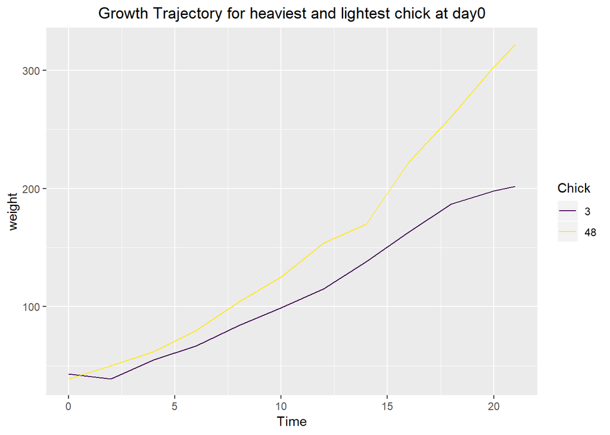

```r
temp1 <- complete %>% arrange(Time)
p2 <-ggplot(complete %>% filter(Chick ==3 | Chick ==48)%>% arrange(Time),aes(x =Time,y =weight ,color =Chick))+geom_line() +ggtitle("Growth Trajectory for heaviest and lightest chick at day0")
p2 <- p2 + theme(plot.title=element_text(hjust=0.5))
p2
```

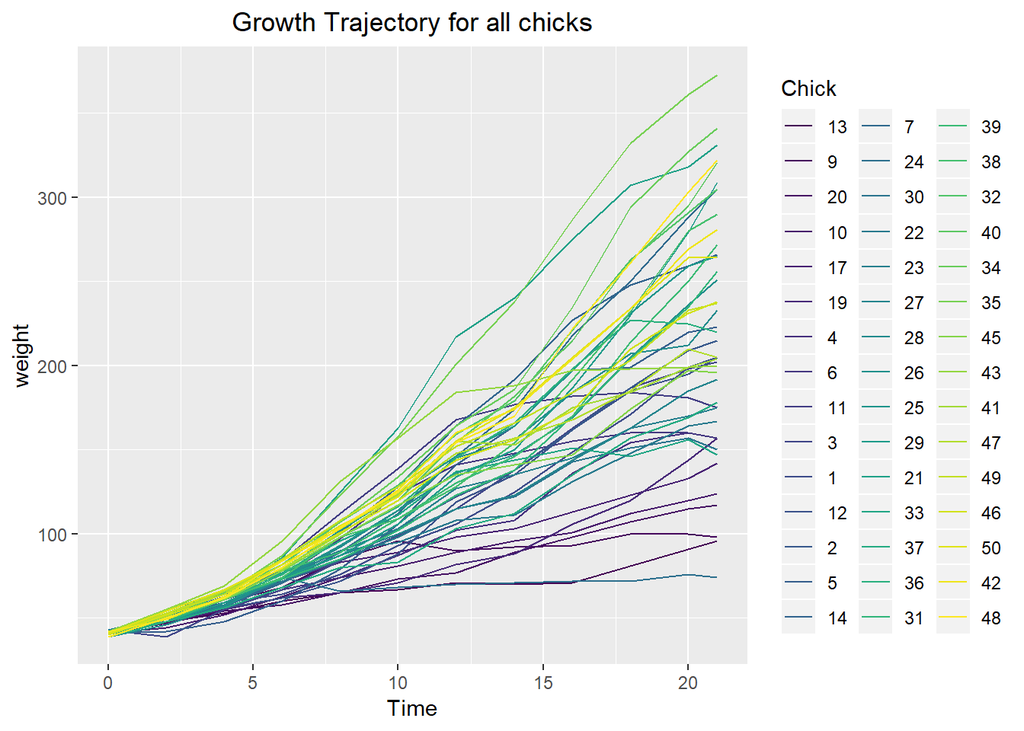

```r
p3 <-ggplot(complete%>% arrange(Time),aes(x =Time,y =weight ,color =Chick))+geom_line() +ggtitle("Growth Trajectory for all chicks")
p3 <- p3 + theme(plot.title = element_text(hjust=0.5))
p3
```

```r
#average growth trajectory for each diet
growth <- data %>%
  group_by(Diet,Time) %>%
  summarise(NumChicks = n()%/%12 ,average_weight = mean(weight),sd_weight = sd(weight))
growth
```

```
## # A tibble: 48 x 5
## # Groups:   Diet [?]
##    Diet   Time NumChicks average_weight sd_weight
##    <fct> <dbl>     <dbl>          <dbl>     <dbl>
##  1 1         0         1           41.4     0.995
##  2 1         2         1           47.2     4.28
##  3 1         4         1           56.5     4.13
##  4 1         6         1           66.8     7.76
##  5 1         8         1           79.7    13.8
##  6 1        10         1           93.1    22.5
##  7 1        12         1          109.     32.6
##  8 1        14         1          123.     37.4
##  9 1        16         1          145.     45.0
## 10 1        18         1          159.     49.2
## # ... with 38 more rows
```

```r
p4 <- ggplot(growth, aes(x = Time,y=average_weight,color = Diet)) +geom_line() + xlab("Time") +ylab("average weight") +ggtitle("average weight against Time")
p4 <- theme(plot.title = element_text(hjust =0.5))
p4
```

[output not shown]

Note: your submission is supposed to be fully reproducible, i.e. the TA and I will ‘knit’ your submission in RStudio.